# EDA Raw Data

2024-03-23

# 1. LIBRARIES

```r
rm(list = ls())
graphics.off()

library(dplyr)
library(xlsx)
library(readxl)
library(plyr)
library(dplyr)
library(tidyr)
library(readr)
library(ggplot2)
library(reshape2)
library(forcats)
library(ggcorrplot)
library(vcd)
```

# 2. EXPLORE ORIGINAL DATASETS

## 2.1. Load datasets

```r
dim_customer <- read.csv(file.path("tables_raw_data", "dim_customers.csv")) %>% as.data.frame()
dim_payments <- read.csv(file.path("tables_raw_data", "dim_payments.csv")) %>% as.data.frame()
dim_products <- read.csv(file.path("tables_raw_data", "dim_products.csv")) %>% as.data.frame()
fct_orders_item <- read.csv(file.path("tables_raw_data", "fct_order_items.csv")) %>% as.data.frame()
fct_orders <- read.csv(file.path("tables_raw_data", "fct_orders.csv")) %>% as.data.frame()
```

## 2.2. Check dataframes

```r
str(fct_orders)
```

```
## 'data.frame':    99441 obs. of  8 variables:
##  $ order_id                     : chr  "e481f51cbdc54678b7cc49136f2d6af7" "53cdb2fc8bc7dce0b6741e2150273451" "47770eb9100c2d0c44946d9cf07ec65d" "949d5b44dbf5de918fe9c16f97b45f8a" ...
##  $ customer_id                  : chr  "9ef432eb6251297304e76186b10a928d" "b0830fb4747a6c6d20dea0b8c802d7ef" "41ce2a54c0b03bf3443c3d931a367089" "f88197465ea7920adcdbec7375364d82" ...
##  $ order_status                 : chr  "delivered" "delivered" "delivered" "delivered" ...
##  $ order_purchase_timestamp     : chr  "2017-10-02 10:56:33" "2018-07-24 20:41:37" "2018-08-08 08:38:49" "2017-11-18 19:28:06" ...
##  $ order_approved_at            : chr  "2017-10-02 11:07:15" "2018-07-26 03:24:27" "2018-08-08 08:55:23" "2017-11-18 19:45:59" ...
##  $ order_delivered_carrier_date : chr  "2017-10-04 19:55:00" "2018-07-26 14:31:00" "2018-08-08 13:50:00" "2017-11-22 13:39:59" ...
##  $ order_delivered_customer_date: chr  "2017-10-10 21:25:13" "2018-08-07 15:27:45" "2018-08-17 18:06:29" "2017-12-02 00:28:42" ...
##  $ order_estimated_delivery_date: chr  "2017-10-18 00:00:00" "2018-08-13 00:00:00" "2018-09-04 00:00:00" "2017-12-15 00:00:00" ...
```

```r
str(fct_orders_item)
```

```
## 'data.frame':    112650 obs. of  7 variables:
##  $ order_id           : chr  "00010242fe8c5a6d1ba2dd792cb16214" "00018f77f2f0320c557190d7a144bdd3" "000229ec398224ef6ca0657da4fc703e" "00024acbcdf0a6daa1e931b038114c75" ...
##  $ order_item_id      : int  1 1 1 1 1 1 1 1 1 1 ...
##  $ product_id         : chr  "4244733e06e7ecb4970a6e2683c13e61" "e5f2d52b802189ee658865ca93d83a8f" "c777355d18b72b67abbeef9df44fd0fd" "7634da152a4610f1595efa32f14722fc" ...
##  $ seller_id          : chr  "48436dade18ac8b2bce089ec2a041202" "dd7ddc04e1b6c2c614352b383efe2d36" "5b51032eddd242adc84c38acab88f23d" "9d7a1d34a5052409006425275ba1c2b4" ...
##  $ shipping_limit_date: chr  "2017-09-19 09:45:35" "2017-05-03 11:05:13" "2018-01-18 14:48:30" "2018-08-15 10:10:18" ...
##  $ price              : num  58.9 239.9 199 13 199.9 ...
##  $ freight_value      : num  13.3 19.9 17.9 12.8 18.1 ...
```

```r
str(dim_customer)
```

```
## 'data.frame':    99441 obs. of  5 variables:
##  $ customer_id             : chr  "06b8999e2fba1a1fbc88172c00ba8bc7" "18955e83d337fd6b2def6b18a428ac77" "4e7b3e00288586ebd08712fdd0374a03" "b2b6027bc5c5109e529d4dc6358b12c3" ...
##  $ customer_unique_id      : chr  "861eff4711a542e4b93843c6dd7febb0" "290c77bc529b7ac935b93aa66c333dc3" "060e732b5b29e8181a18229c7b0b2b5e" "259dac757896d24d7702b9acbbff3f3c" ...
##  $ customer_zip_code_prefix: int  14409 9790 1151 8775 13056 89254 4534 35182 81560 30575 ...
##  $ customer_city           : chr  "franca" "sao bernardo do campo" "sao paulo" "mogi das cruzes" ...
##  $ customer_state          : chr  "SP" "SP" "SP" "SP" ...
```

```r
str(dim_products)
```

```
## 'data.frame':    32951 obs. of  9 variables:
##  $ product_id                : chr  "1e9e8ef04dbcff4541ed26657ea517e5" "3aa071139cb16b67ca9e5dea641aaa2f" "96bd76ec8810374ed1b65e291975717f" "cef67bcfe19066a932b7673e239eb23d" ...
##  $ product_category_name     : chr  "perfumaria" "artes" "esporte_lazer" "bebes" ...
##  $ product_name_lenght       : int  40 44 46 27 37 60 56 56 57 36 ...
##  $ product_description_lenght: int  287 276 250 261 402 745 1272 184 163 1156 ...
##  $ product_photos_qty        : int  1 1 1 1 4 1 4 2 1 1 ...
##  $ product_weight_g          : int  225 1000 154 371 625 200 18350 900 400 600 ...
##  $ product_length_cm         : int  16 30 18 26 20 38 70 40 27 17 ...
##  $ product_height_cm         : int  10 18 9 4 17 5 24 8 13 10 ...
##  $ product_width_cm          : int  14 20 15 26 13 11 44 40 17 12 ...
```

```r
str(dim_payments)
```

```
## 'data.frame':    103886 obs. of  5 variables:
##  $ order_id            : chr  "b81ef226f3fe1789b1e8b2acac839d17" "a9810da82917af2d9aefd1278f1dcfa0" "25e8ea4e93396b6fa0d3dd708e76c1bd" "ba78997921bbcdc1373bb41e913ab953" ...
##  $ payment_sequential  : int  1 1 1 1 1 1 1 1 1 1 ...
##  $ payment_type        : chr  "credit_card" "credit_card" "credit_card" "credit_card" ...
##  $ payment_installments: int  8 1 1 8 2 2 1 3 6 1 ...
##  $ payment_value       : num  99.3 24.4 65.7 107.8 128.4 ...
```

## 2.3.EDA

### 2.3.1.Missing values

```r
# fct_orders
colSums(is.na(fct_orders)) %>% as.data.frame
```

```
##                               .
## order_id                      0
## customer_id                   0
## order_status                  0
## order_purchase_timestamp      0
## order_approved_at             0
## order_delivered_carrier_date  0
## order_delivered_customer_date 0
## order_estimated_delivery_date 0
```

```r
# fct_orders_item
colSums(is.na(fct_orders_item)) %>% as.data.frame
```

```
##                     .
## order_id            0
## order_item_id       0
## product_id          0
## seller_id           0
## shipping_limit_date 0
## price               0
## freight_value       0
```

```r
# dim_customer
colSums(is.na(dim_customer)) %>% as.data.frame
```

```
##                          .
## customer_id              0
## customer_unique_id       0
## customer_zip_code_prefix 0
## customer_city            0
## customer_state           0
```

```r
# dim_products
colSums(is.na(dim_products)) %>% as.data.frame
```

```
##                              .
## product_id                   0
## product_category_name        0
## product_name_lenght        610
## product_description_lenght 610
## product_photos_qty         610
## product_weight_g             2
## product_length_cm            2
## product_height_cm            2
## product_width_cm             2
```

```r
# dim_payments
colSums(is.na(dim_payments)) %>% as.data.frame
```

```
##                      .
## order_id             0
## payment_sequential   0
## payment_type         0
## payment_installments 0
## payment_value        0
```

**Comments:** Missing values were only found in dim_products..

### 2.3.2. Distribution of variables’ values

#### 2.3.2.1. fct_orders

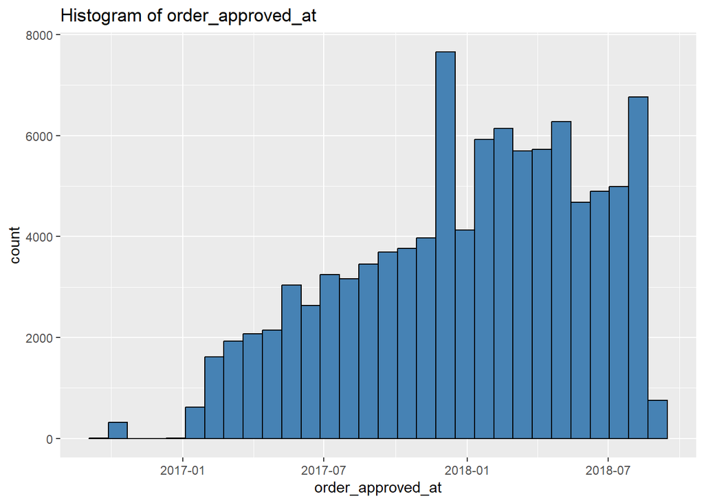

```r
# convert POSIXct to Date
fct_orders$order_approved_at<- as.Date(fct_orders$order_approved_at)
fct_orders$order_delivered_carrier_date <- as.Date(fct_orders$order_delivered_carrier_date)
fct_orders$order_delivered_customer_date <- as.Date(fct_orders$order_delivered_customer_date)
fct_orders$order_estimated_delivery_date <- as.Date(fct_orders$order_estimated_delivery_date)
fct_orders$order_purchase_timestamp <- as.Date(fct_orders$order_purchase_timestamp)

# Histogram --------------------------------------------------------------
ggplot(data=fct_orders, aes(x=order_approved_at)) +
 geom_histogram(fill="steelblue", color="black", bin=40) +
 ggtitle("Histogram of order_approved_at")
```

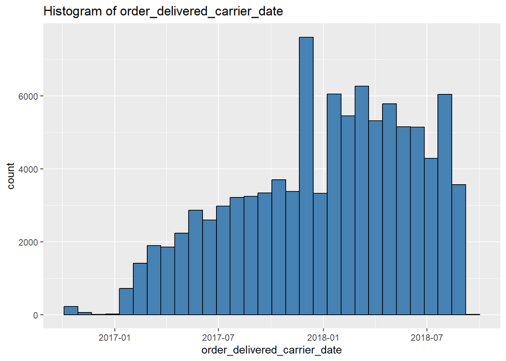

```r
ggplot(data=fct_orders, aes(x=order_delivered_carrier_date)) +
 geom_histogram(fill="steelblue", color="black", bin=40) +
 ggtitle("Histogram of order_delivered_carrier_date")
```

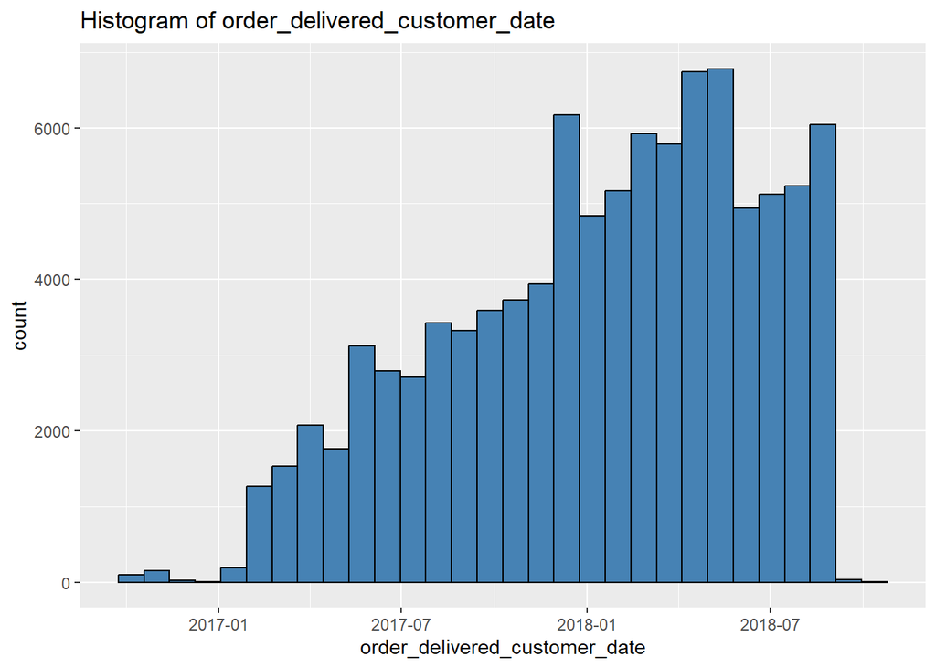

```r
ggplot(data=fct_orders, aes(x=order_delivered_customer_date)) +
 geom_histogram(fill="steelblue", color="black", bin=40) +
 ggtitle("Histogram of order_delivered_customer_date")
```

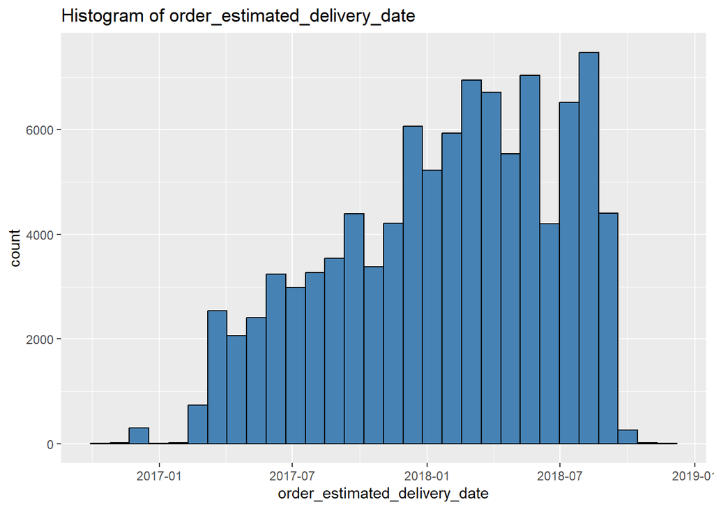

```r
ggplot(data=fct_orders, aes(x=order_estimated_delivery_date)) +
 geom_histogram(fill="steelblue", color="black", bin=40) +
 ggtitle("Histogram of order_estimated_delivery_date")
```

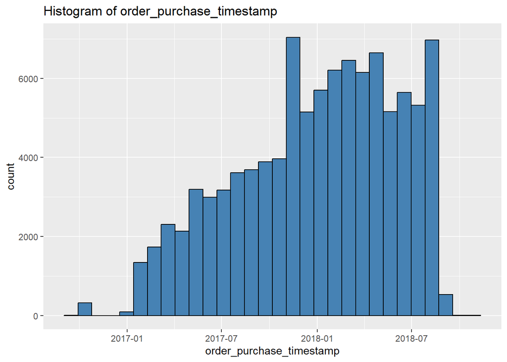

```r
ggplot(data=fct_orders, aes(x=order_purchase_timestamp )) +
 geom_histogram(fill="steelblue", color="black", bin=40) +
 ggtitle("Histogram of order_purchase_timestamp")
```

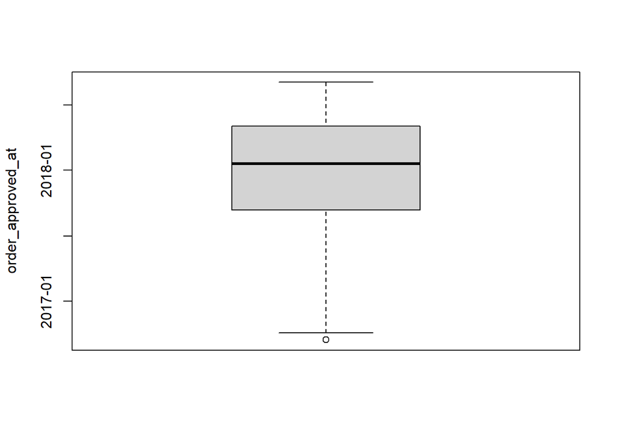

```r
# Boxplots --------------------------------------------------------------
boxplot(fct_orders$order_approved_at,
  ylab = "order_approved_at")
```

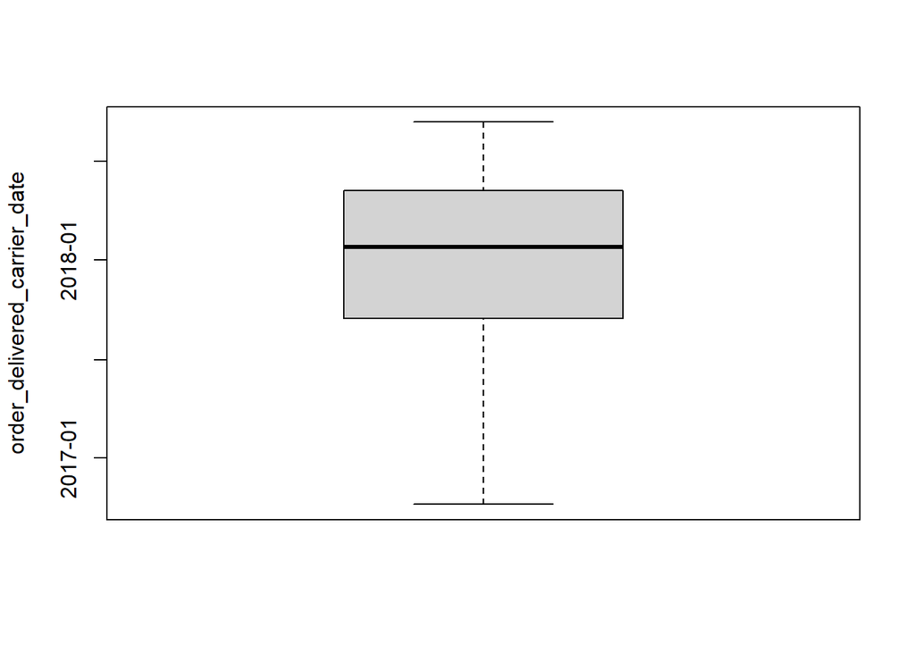

```r
boxplot(fct_orders$order_delivered_carrier_date,
  ylab = "order_delivered_carrier_date")
```

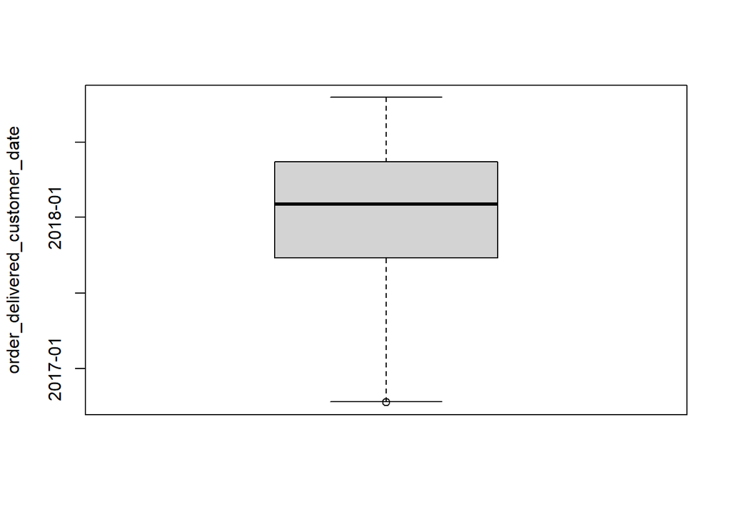

```r
boxplot(fct_orders$order_delivered_customer_date,
  ylab = "order_delivered_customer_date")
```

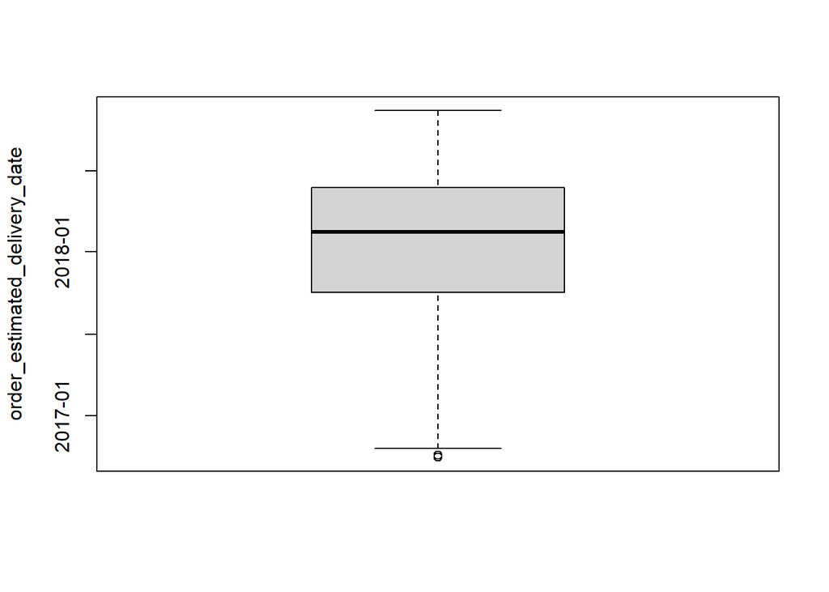

```r
boxplot(fct_orders$order_estimated_delivery_date,
  ylab = "order_estimated_delivery_date")
```

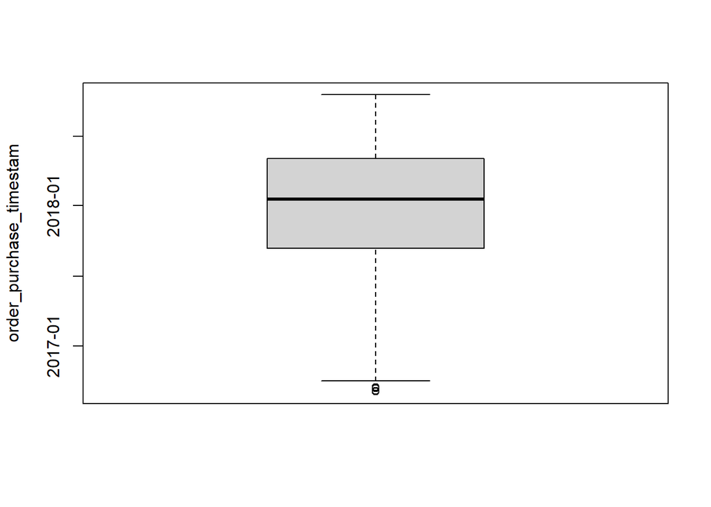

```r
boxplot(fct_orders$order_purchase_timestamp,
  ylab = "order_purchase_timestam")
```

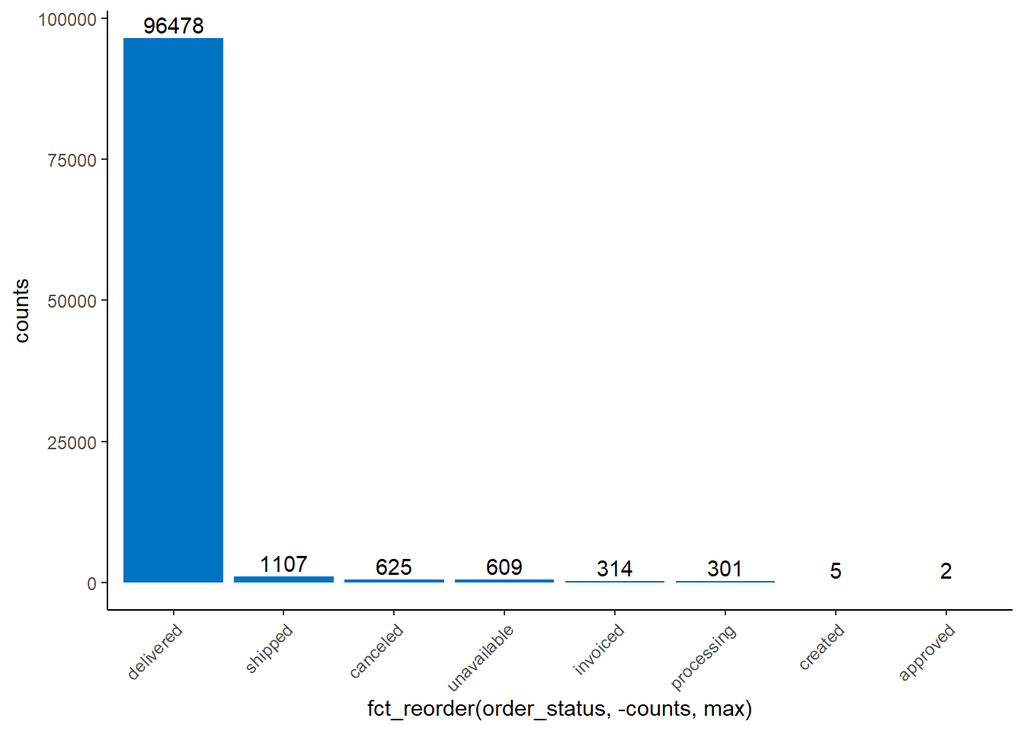

```r
# Frequency --------------------------------------------------------------
# Compute the frequency
order_status <- fct_orders %>%
        group_by(order_status) %>%
        dplyr::summarise(counts = n()) %>%
        arrange(desc(counts))


# Create the bar plot
ggplot(order_status, aes(x =fct_reorder(order_status, -counts, max), y = counts)) +
  geom_bar(fill = "#0073C2FF", stat = "identity") +
  geom_text(aes(label = counts), vjust = -0.3) +
  scale_x_discrete(guide = guide_axis(angle = 45)) +
  theme_classic()
```

**Comments:** . Data is skewed to the left. . Few outliers were found. . The majority of orders were delivered.

#### 2.3.2.2. fct_orders_item

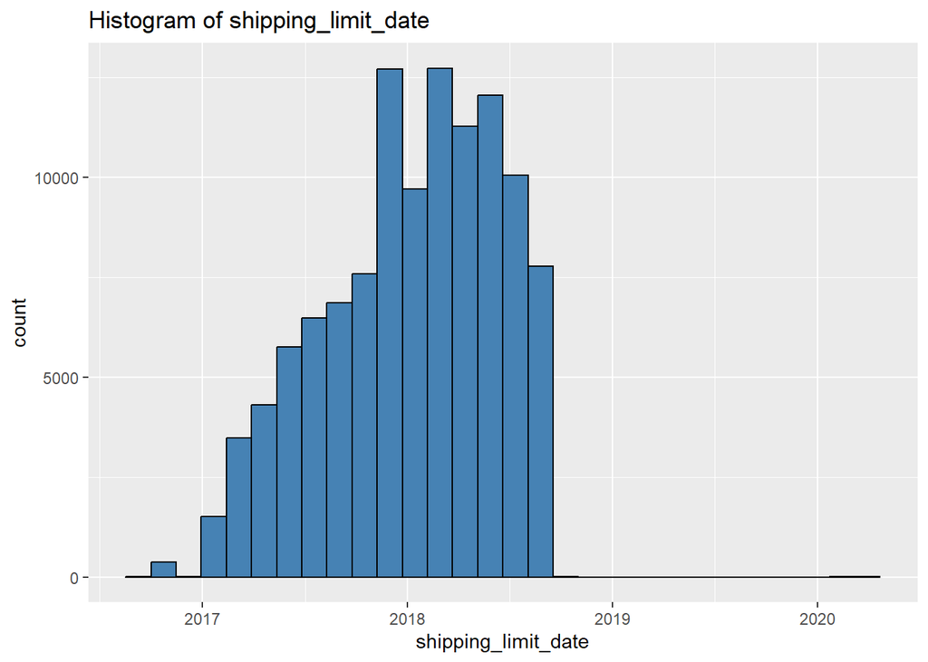

```r
# convert POSIXct to Date
fct_orders_item$shipping_limit_date <- as.Date(fct_orders_item$shipping_limit_date)

ggplot(data=fct_orders_item, aes(x=shipping_limit_date)) +
 geom_histogram(fill="steelblue", color="black", bin=40) +
 ggtitle("Histogram of shipping_limit_date")
```

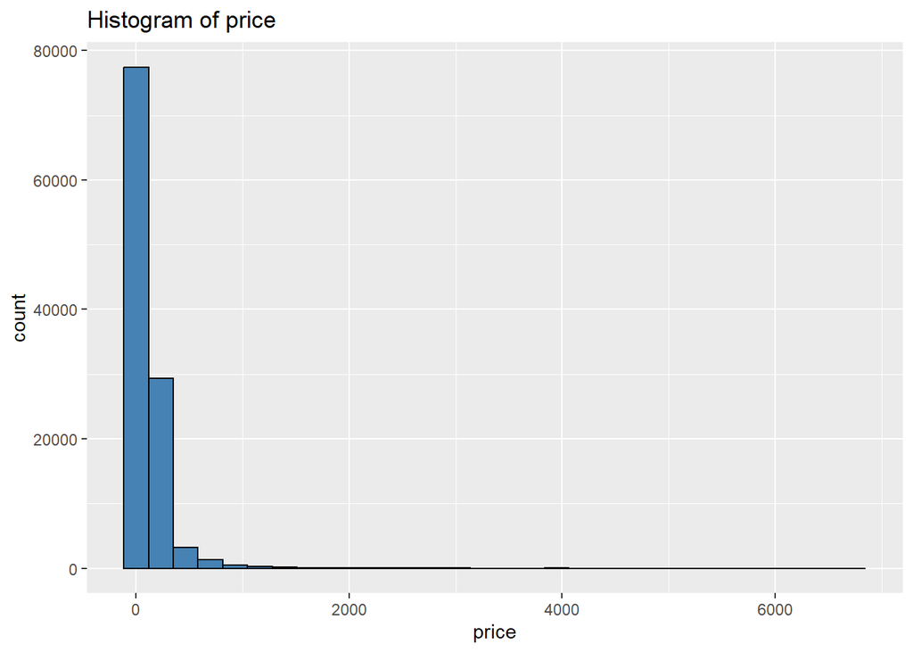

```r
ggplot(data=fct_orders_item, aes(x=price)) +
 geom_histogram(fill="steelblue", color="black", bin=40) +
 ggtitle("Histogram of price")
```

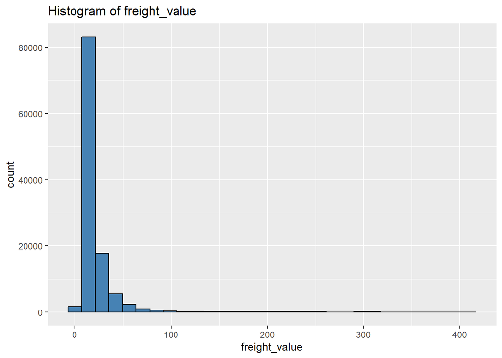

```r
ggplot(data=fct_orders_item, aes(x=freight_value)) +
 geom_histogram(fill="steelblue", color="black", bin=40) +
 ggtitle("Histogram of freight_value")
```

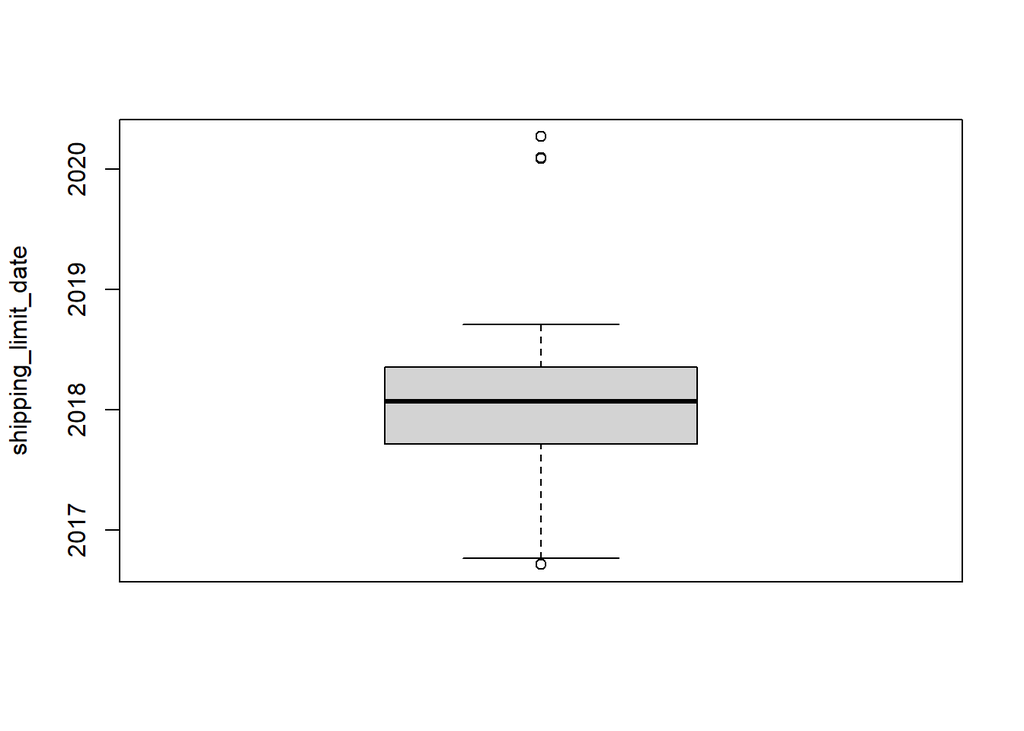

```r
# Boxplots --------------------------------------------------------------

boxplot(fct_orders_item$shipping_limit_date,
  ylab = "shipping_limit_date")
```

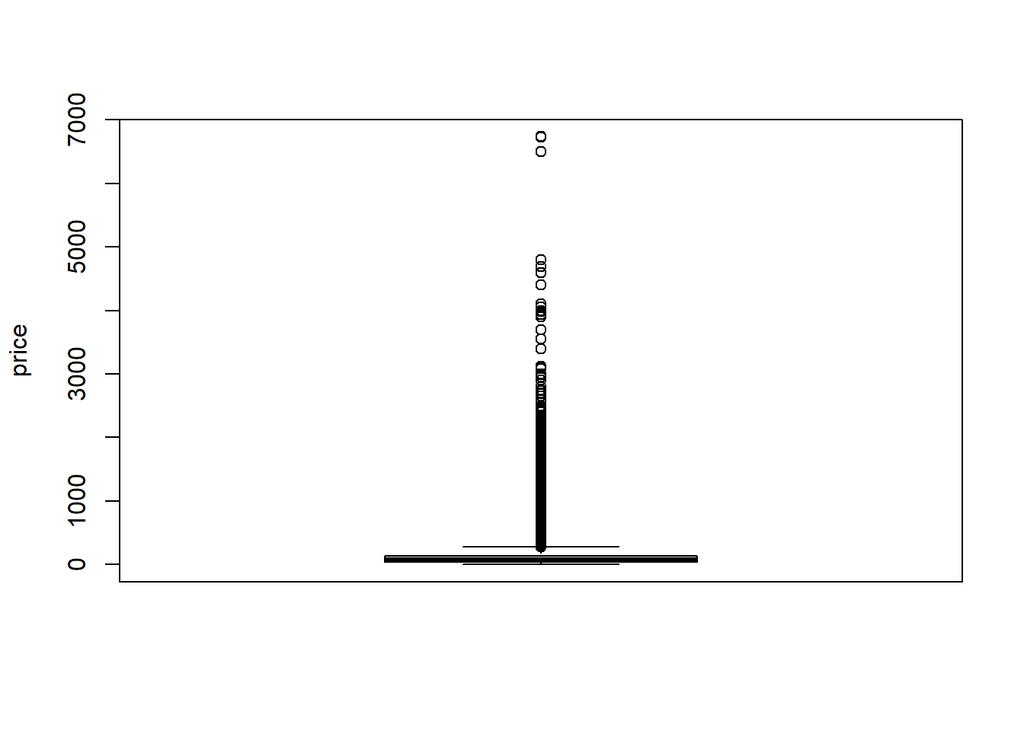

```r
boxplot(fct_orders_item$price,
  ylab = "price")
```

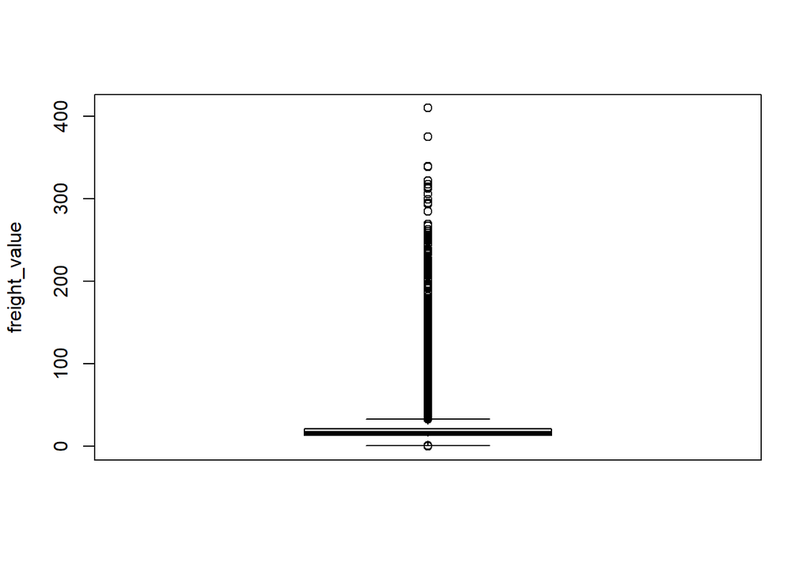

```r
boxplot(fct_orders_item$freight_value,
  ylab = "freight_value")
```

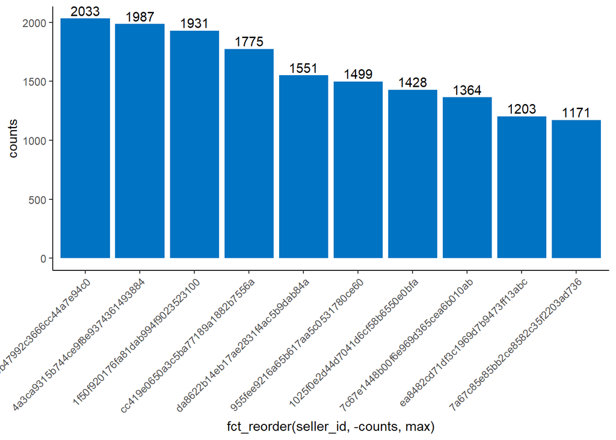

```r
# Frequency --------------------------------------------------------------
# Compute the frequency
seller_id <- fct_orders_item %>%
        group_by(seller_id) %>%
        dplyr::summarise(counts = n()) %>%
        arrange(desc(counts))

# Top 10
top_10_seller_id <- seller_id[c(1:10),]


# Create the bar plot
ggplot(top_10_seller_id, aes(x =fct_reorder(seller_id, -counts, max), y = counts)) +
  geom_bar(fill = "#0073C2FF", stat = "identity") +
  geom_text(aes(label = counts), vjust = -0.3) +
  scale_x_discrete(guide = guide_axis(angle = 45)) +
  theme_classic()
```

**Comments:** . Some of the data is skewed to the right and other to the left. . An high number of outliers were found (price and freight_values). . There is not a clear prevalence of orders by one seller (or group of sellers).

#### 2.3.2.3. dim_customer

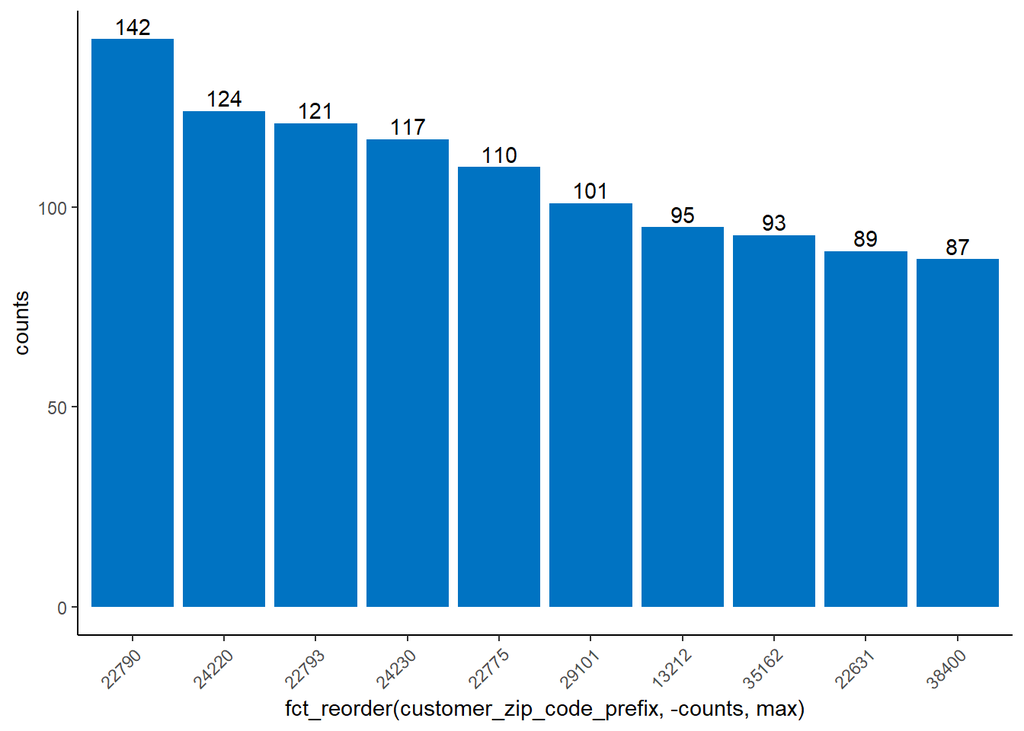

```r
# Frequency --------------------------------------------------------------
# Compute the frequency
customer_zip_code_prefix <- dim_customer %>%
        group_by(customer_zip_code_prefix) %>%
        dplyr::summarise(counts = n()) %>%
        arrange(desc(counts))

customer_city <- dim_customer %>%
        group_by(customer_city) %>%
        dplyr::summarise(counts = n()) %>%
        arrange(desc(counts))

customer_state <- dim_customer %>%
        group_by(customer_state) %>%
        dplyr::summarise(counts = n()) %>%
        arrange(desc(counts))

# Top 10
top_10_customer_zip_code_prefix <- customer_zip_code_prefix[c(1:10),]
top_10_customer_zip_code_prefix$customer_zip_code_prefix <- as.factor(top_10_customer_zip_code_prefix$customer_zip_code_prefix )

top_10_customer_city <- customer_city[c(1:10),]

top_10_customer_state <- customer_state[c(1:10),]


# Create the bar plot
ggplot(top_10_customer_zip_code_prefix, aes(fct_reorder(customer_zip_code_prefix, -counts, max), y = counts)) +
  geom_bar(fill = "#0073C2FF", stat = "identity") +
  geom_text(aes(label = counts), vjust = -0.3) +
  scale_x_discrete(guide = guide_axis(angle = 45)) +
  theme_classic()
```

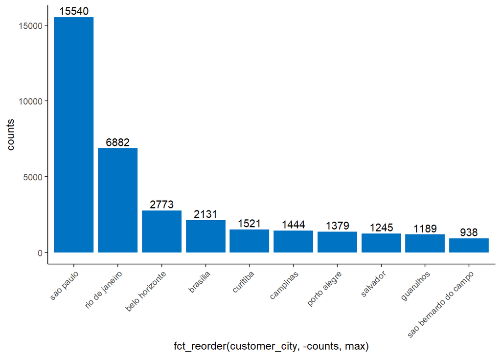

```r
ggplot(top_10_customer_city, aes(fct_reorder(customer_city, -counts, max), y = counts)) +
  geom_bar(fill = "#0073C2FF", stat = "identity") +
  geom_text(aes(label = counts), vjust = -0.3) +
  scale_x_discrete(guide = guide_axis(angle = 45)) +
  theme_classic()
```

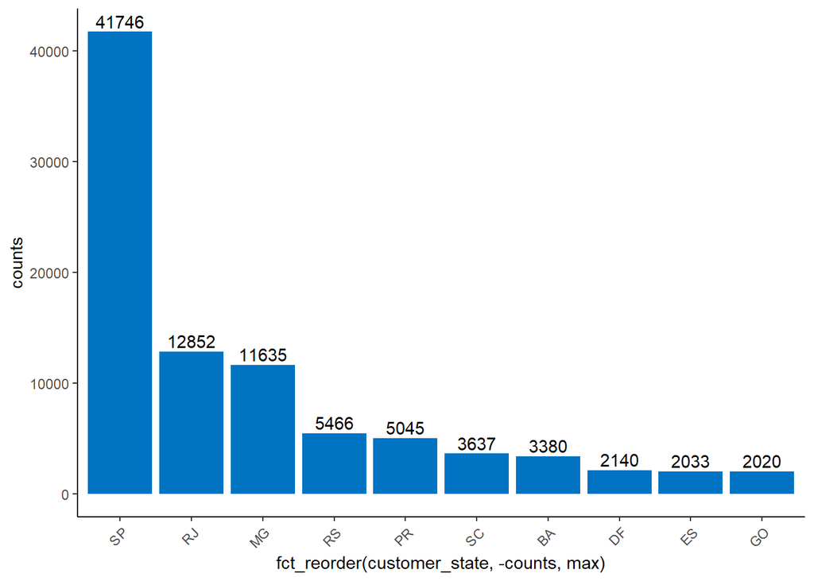

```r
ggplot(top_10_customer_state, aes(fct_reorder(customer_state, -counts, max), y = counts)) +
  geom_bar(fill = "#0073C2FF", stat = "identity") +
  geom_text(aes(label = counts), vjust = -0.3) +
  scale_x_discrete(guide = guide_axis(angle = 45)) +
  theme_classic()
```

#### 2.3.2.3. dim_payments

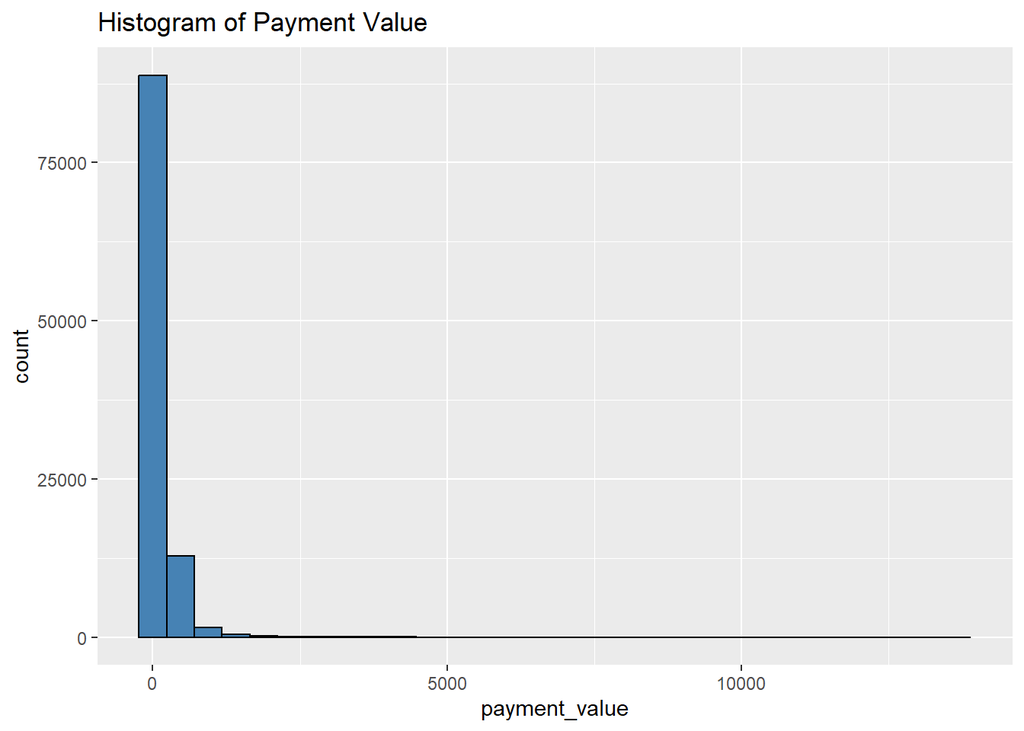

```r
# Histogram --------------------------------------------------------------
ggplot(data=dim_payments, aes(x=payment_value)) +
 geom_histogram(fill="steelblue", color="black", bin=40) +
 ggtitle("Histogram of Payment Value")
```

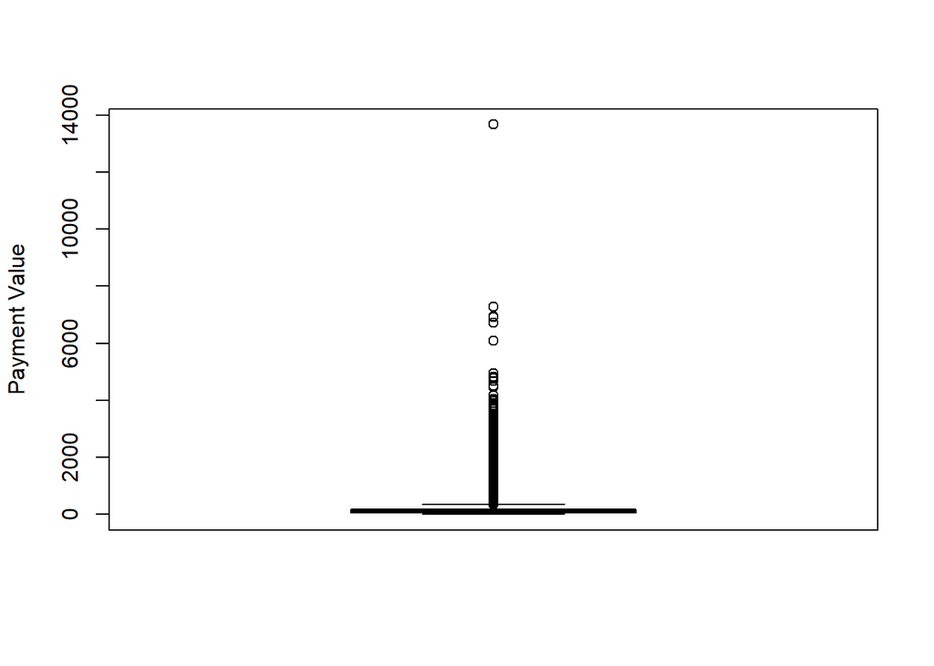

```r
# Boxplots --------------------------------------------------------------
boxplot(dim_payments$payment_value,
  ylab = "Payment Value"
)
```

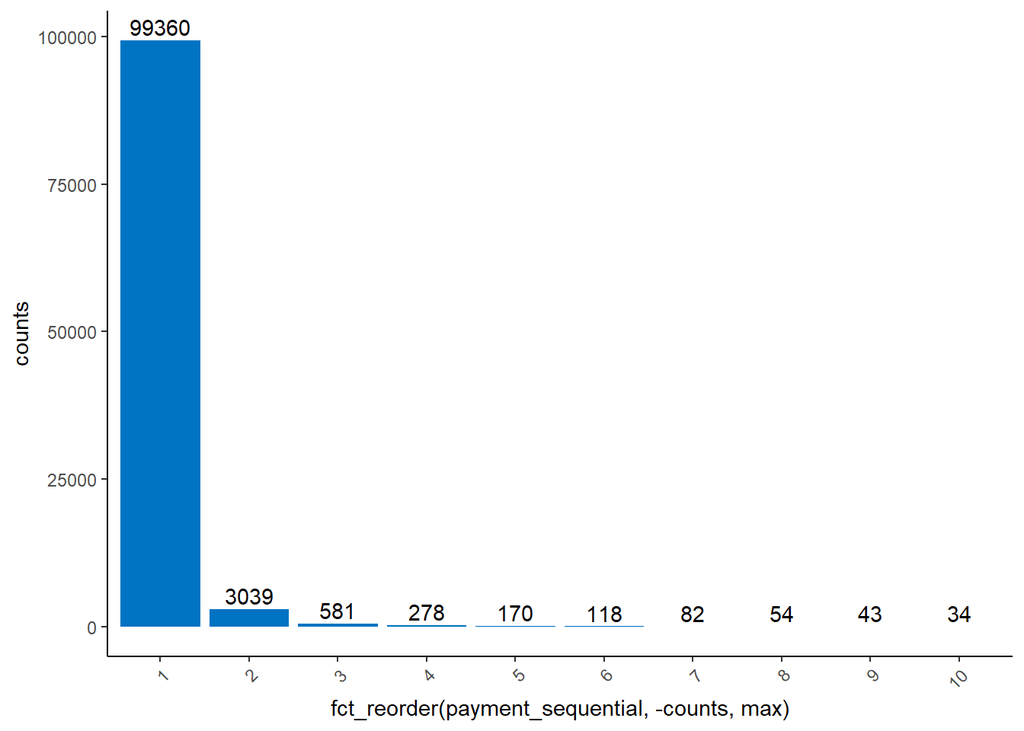

```r
# Frequency --------------------------------------------------------------
# Compute the frequency
payment_sequential <- dim_payments %>%
        group_by(payment_sequential) %>%
        dplyr::summarise(counts = n()) %>%
        arrange(desc(counts))

payment_type <- dim_payments %>%
        group_by(payment_type) %>%
        dplyr::summarise(counts = n()) %>%
        arrange(desc(counts))

payment_installments <- dim_payments %>%
        group_by(payment_installments) %>%
        dplyr::summarise(counts = n()) %>%
        arrange(desc(counts))

# Top 10
top_10_payment_sequential<- payment_sequential[c(1:10),]
top_10_payment_sequential$payment_sequential <- as.factor(top_10_payment_sequential$payment_sequential)

top_10_payment_installments<- payment_installments[c(1:10),]
top_10_payment_installments$payment_installments <- as.factor(top_10_payment_installments$payment_installments)


# Create the bar plot
ggplot(top_10_payment_sequential, aes(x = fct_reorder(payment_sequential, -counts, max), y = counts))+
  geom_bar(fill = "#0073C2FF", stat = "identity") +
  geom_text(aes(label = counts), vjust = -0.3) +
  scale_x_discrete(guide = guide_axis(angle = 45)) +
  theme_classic()
```

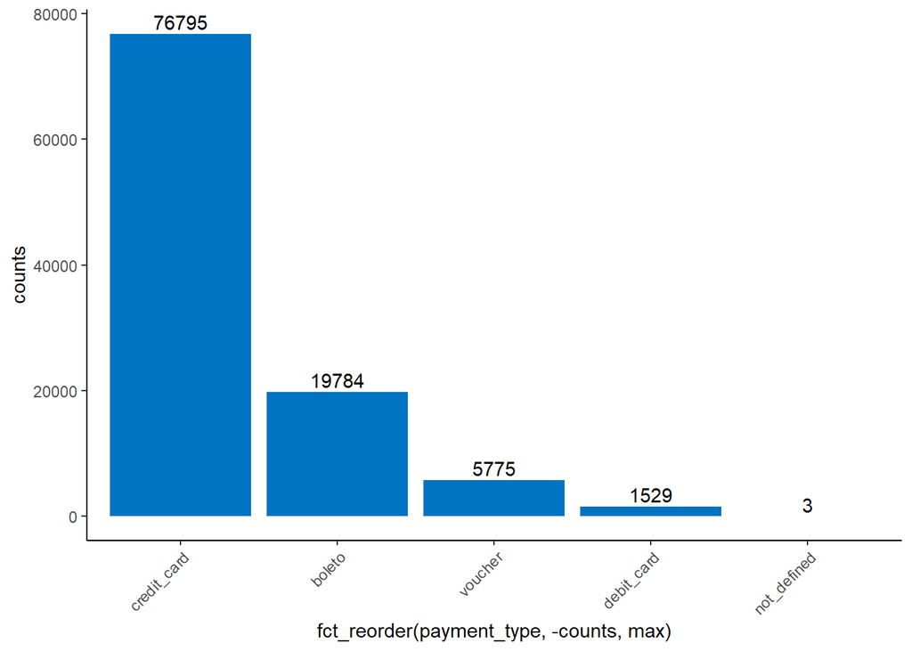

```r
ggplot(payment_type , aes(x = fct_reorder(payment_type, -counts, max), y = counts)) +
  geom_bar(fill = "#0073C2FF", stat = "identity") +
  geom_text(aes(label = counts), vjust = -0.3) +
  scale_x_discrete(guide = guide_axis(angle = 45)) +
  theme_classic()
```

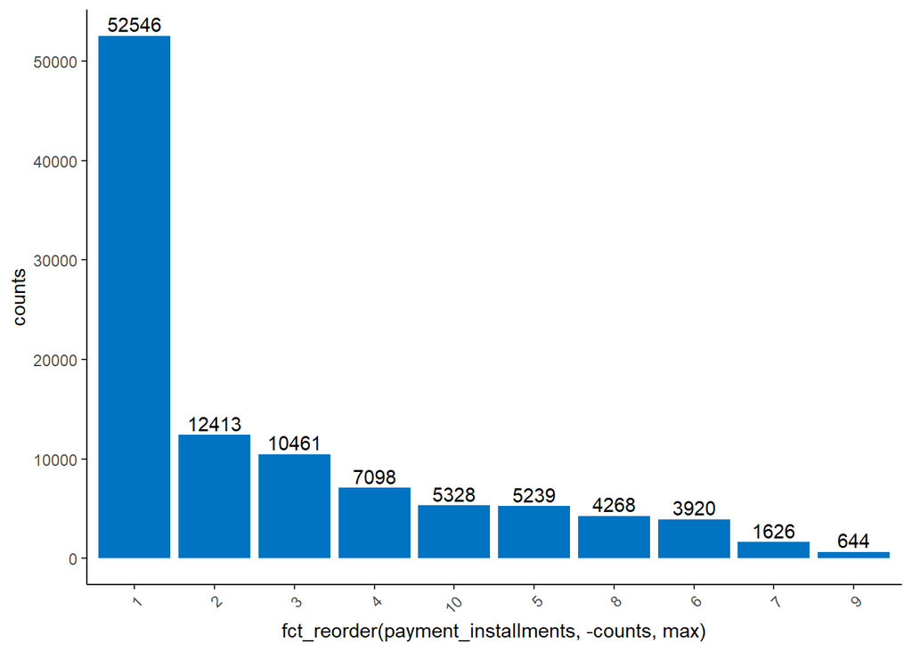

```r
ggplot(top_10_payment_installments, aes(x = fct_reorder(payment_installments, -counts, max), y = counts)) +
  geom_bar(fill = "#0073C2FF", stat = "identity") +
  geom_text(aes(label = counts), vjust = -0.3) +
  scale_x_discrete(guide = guide_axis(angle = 45)) +
  theme_classic()
```

**Comments:** . An high number of outliers were found (payment_value). . Most of the orders were made in 1 payment sequential. . Most of the orders were made using credit card, followed by boleto, voucher, and debit card.

#### 2.3.2.3. dim_products

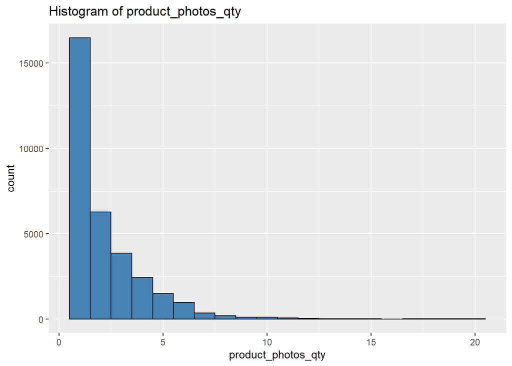

```r
# Histogram --------------------------------------------------------------
ggplot(data=dim_products, aes(x=product_photos_qty)) +
 geom_histogram(fill="steelblue", color="black", binwidth = 1) +
 ggtitle("Histogram of product_photos_qty")
```

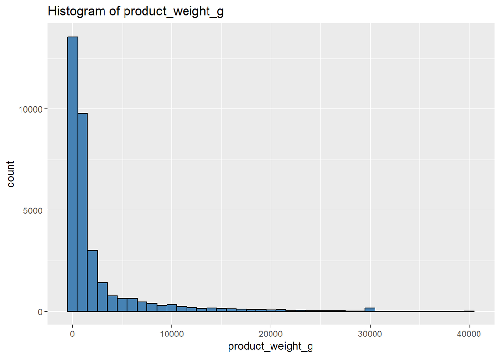

```r
ggplot(data=dim_products, aes(x=product_weight_g)) +
 geom_histogram(fill="steelblue", color="black", binwidth = 1000) +
 ggtitle("Histogram of product_weight_g")
```

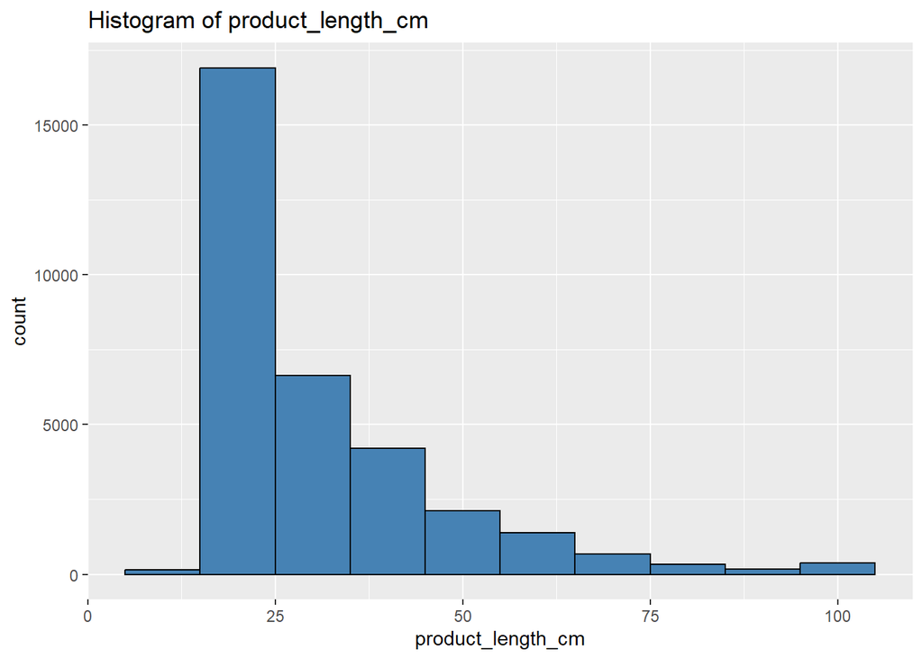

```r
ggplot(data=dim_products, aes(x=product_length_cm)) +
 geom_histogram(fill="steelblue", color="black", binwidth = 10) +
 ggtitle("Histogram of product_length_cm")
```

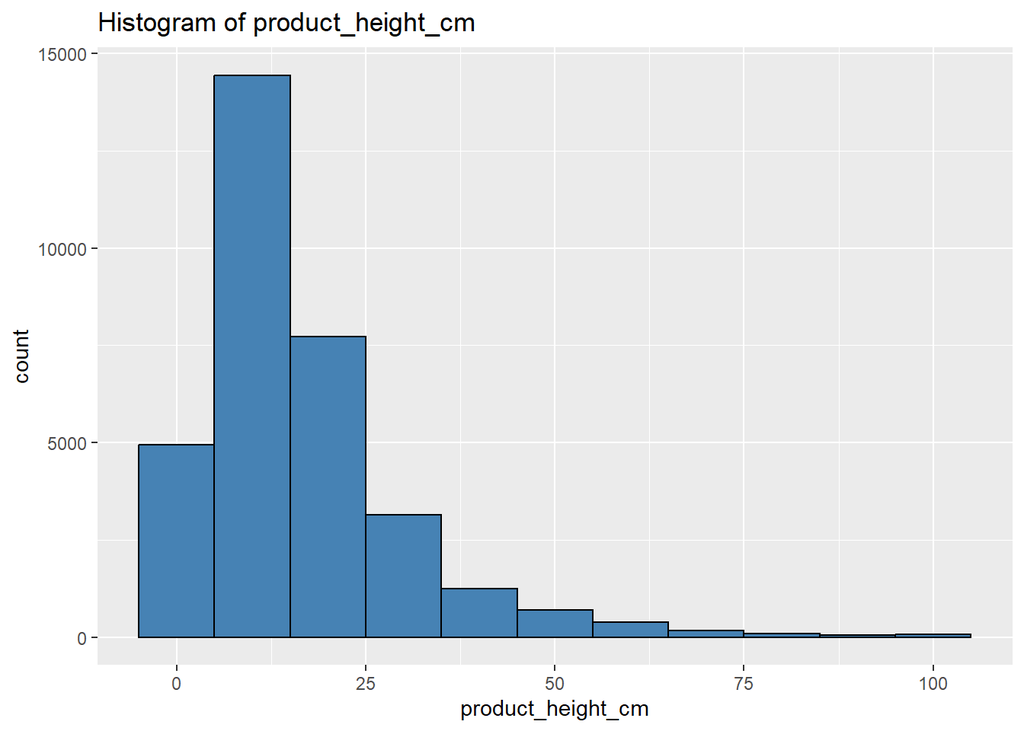

```r
ggplot(data=dim_products, aes(x=product_height_cm)) +
 geom_histogram(fill="steelblue", color="black", binwidth = 10) +
 ggtitle("Histogram of product_height_cm")
```